# Introduction to Solving Biological Problems Using R - Day 2

Mark Dunning, Suraj Menon and Aiora Zabala. Original material by Robert Stojnić, Laurent Gatto, Rob Foy John Davey, Dávid Molnár and Ian Roberts

Last modified: 17 Mar 2016

# Day 2 Schedule

1. Further customisation of plots
2. Statistics
3. Data Manipulation Techniques
4. Programming in R
5. Further report writing

# 1. Further customisation of plots

# Recap

- We have seen how to use `plot()`, `boxplot()` , `hist()` etc to make simple plots
- These come with arguments that can be used to change the appearance of the plot
  - `col`, `pch`
  - `main`, `xlab`, `ylab`
  - etc….
- We will now look at ways to modify the plot appearance after it has been created
- Also, how to export the graphs

# The painter’s model

- R employs a painter’s model to construct it’s plots
- Elements of the graph are added to the canvas one layer at a time, and the picture built up in levels.
- Lower levels are obscured by higher levels,
  - allowing for blending, masking and overlaying of objects.

# Example data

- We will re-use the patients data from yesterday:

```r
age    <- c(50, 21, 35, 45, 28, 31, 42, 33, 57, 62)
weight <- c(70.8, 67.9, 75.3, 61.9, 72.4, 69.9, 63.5,
            71.5, 73.2, 64.8)
firstName  <- c("Adam", "Eve", "John", "Mary", "Peter",
                "Paul", "Joanna", "Matthew", "David", "Sally")
secondName <- c("Jones", "Parker", "Evans", "Davis",
                "Baker","Daniels", "Edwards", "Smith",
                "Roberts", "Wilson")

consent <- c(TRUE, TRUE, FALSE, TRUE, FALSE, FALSE,
             FALSE, TRUE, FALSE, TRUE)

sex <- c("Male", "Female", "Male", "Female", "Male",
         "Male", "Female", "Male", "Male", "Female")
```

# Example data

```r
patients <- data.frame(First_Name = firstName,
                       Second_Name = secondName,
                       Full_Name = paste(firstName, secondName),
                       Sex = factor(sex),
                       Age = age,
                       Weight = weight,
                       Consent = consent,
                       stringsAsFactors = FALSE)
```

# Initial plot

- Recall our patients dataset from yesterday
  - we might want to display other characteristics on the plot, e.g. gender of individual:

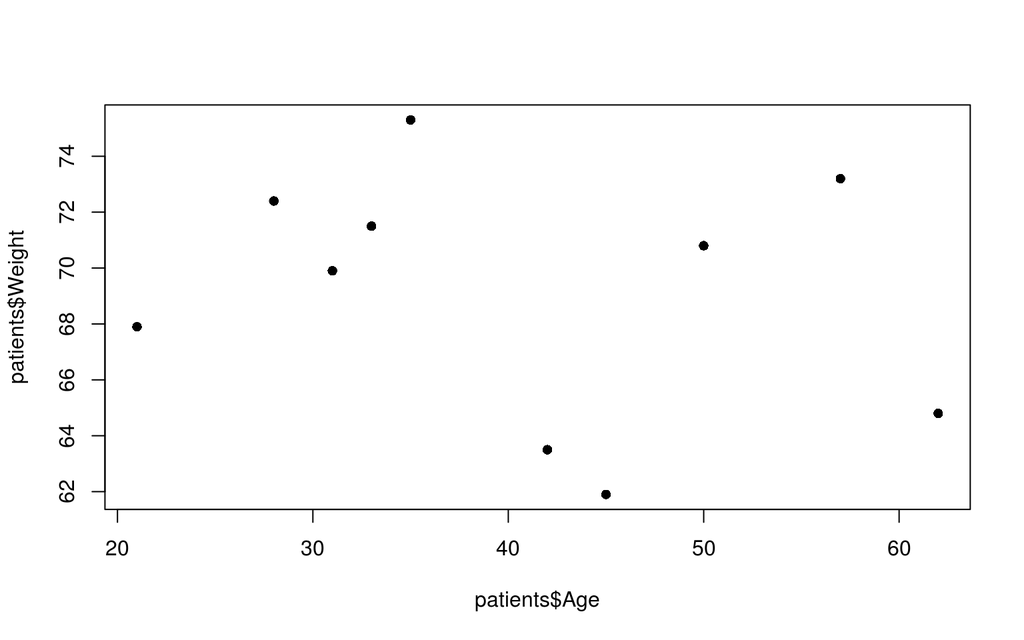

```r
plot(patients$Age, patients$Weight, pch=16)
```

# The points function

- `points()` can be used to set of points to an *existing* plot
- It requires a vector of x and y coordinates
  - These do not have to be the same length as the number of points in the initial plot:
    - Hence we can use `points()` to highlight observations
    - …or add a set of new observations

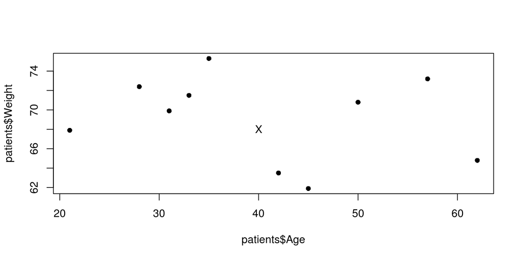

```r
plot(patients$Age, patients$Weight, pch=16)
points(40,68, pch="X")
```

- Note that axis limits of the existing plot are not altered

# Creating a blank plot

- Often it is useful to create a blank ‘canvas’ with the correct labels and limits

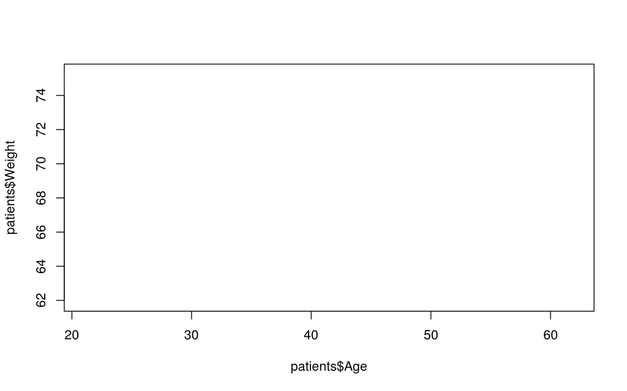

```r
plot(patients$Age, patients$Weight, type="n")
```

# Adding points to differentiate gender

- Selecting males using the **`==`** comparison we saw yesterday
  - Gives a `TRUE` or `FALSE` value
  - Can be used to index the data frame
  - Which means we can get the relevant Age and Weight values

```r
males <- patients$Sex == "Male"
```

```r
males
patients[males,]
patients[males, "Age"]
patients[males, "Weight"]
```

# Adding points to differentiate gender

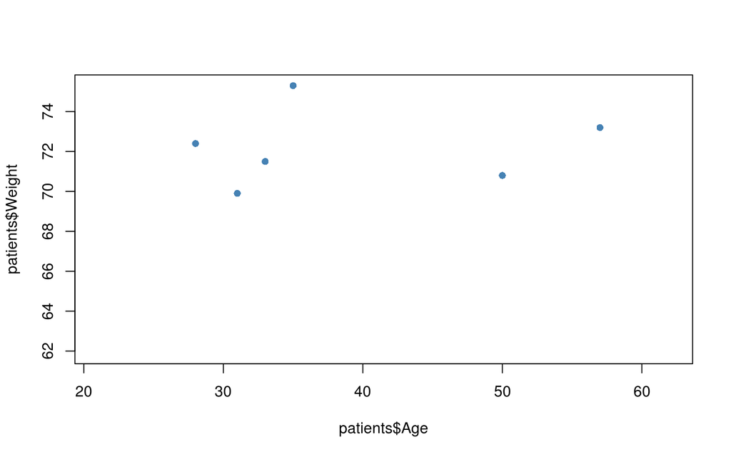

```r
plot(patients$Age, patients$Weight, type="n")
points(patients$Age[males], patients$Weight[males],
       pch=16, col="steelblue")
```

# Adding points to differentiate gender

```r
females <- patients$Sex == "Female"
females
```

```
 [1] FALSE  TRUE FALSE  TRUE FALSE FALSE  TRUE FALSE FALSE  TRUE
```

```r
patients[females,]
```

```
   First_Name Second_Name      Full_Name    Sex Age Weight Consent
2         Eve      Parker     Eve Parker Female  21   67.9    TRUE
4        Mary       Davis     Mary Davis Female  45   61.9    TRUE
7      Joanna     Edwards Joanna Edwards Female  42   63.5   FALSE
10      Sally      Wilson   Sally Wilson Female  62   64.8    TRUE
```

# Adding points to differentiate gender

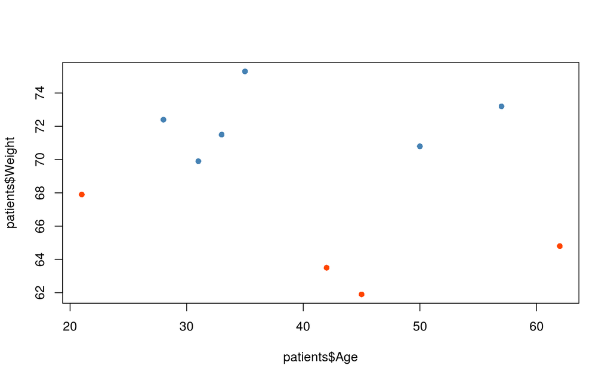

```r
plot(patients$Age, patients$Weight, type="n")
points(patients$Age[males], patients$Weight[males],
       pch=16, col="steelblue")
points(patients$Age[females], patients$Weight[females],
       pch=16, col="orangered1")
```

# Adding points

- Each set of points can have a different colour and shape
- Axis labels and title and limits are defined by the plot
- You can add points ad-nauseum. Try not to make the plot cluttered!
- Once you’ve added points to a plot, they cannot be removed
- A call to `plot` will start a new graphics window
  - or typing `dev.off()`

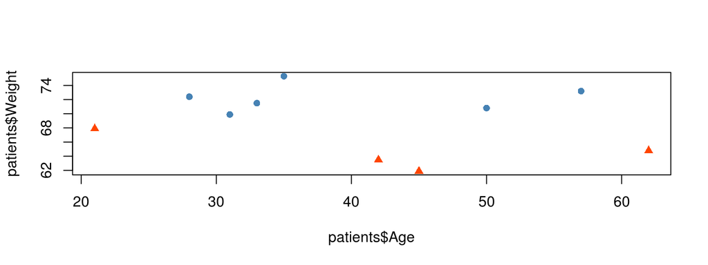

```r
plot(patients$Age, patients$Weight, type="n")
points(patients$Age[males], patients$Weight[males],
       pch=16, col="steelblue")
points(patients$Age[females], patients$Weight[females],
       pch=17, col="orangered1")
```

- TIP: try building the same plot, but using a vector of colors fo the attribute `col`, instead of subselecting the observations

# Adding a legend

- Should also add a legend to help interpret the plot
  - use the `legend` function
  - can give x and y coordinates where legend will appear
  - also recognises shortcuts such as *topleft* and *bottomright*…

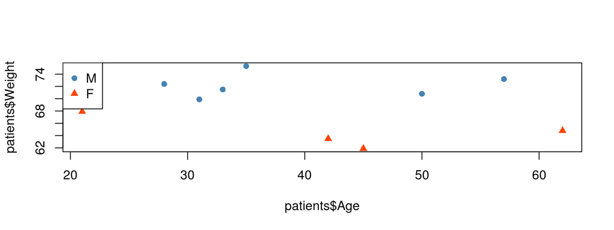

```r
plot(patients$Age, patients$Weight, type="n")
points(patients$Age[males], patients$Weight[males],
       pch=16, col="steelblue")
points(patients$Age[females], patients$Weight[females],
       pch=17, col="orangered1")
legend("topleft", legend=c("M","F"),
       col=c("steelblue","orangered1"), pch=c(16,17))
```

# Adding text

- Text can also be added to a plot in a similar manner
  - The `labels` argument specifies the text we want to add

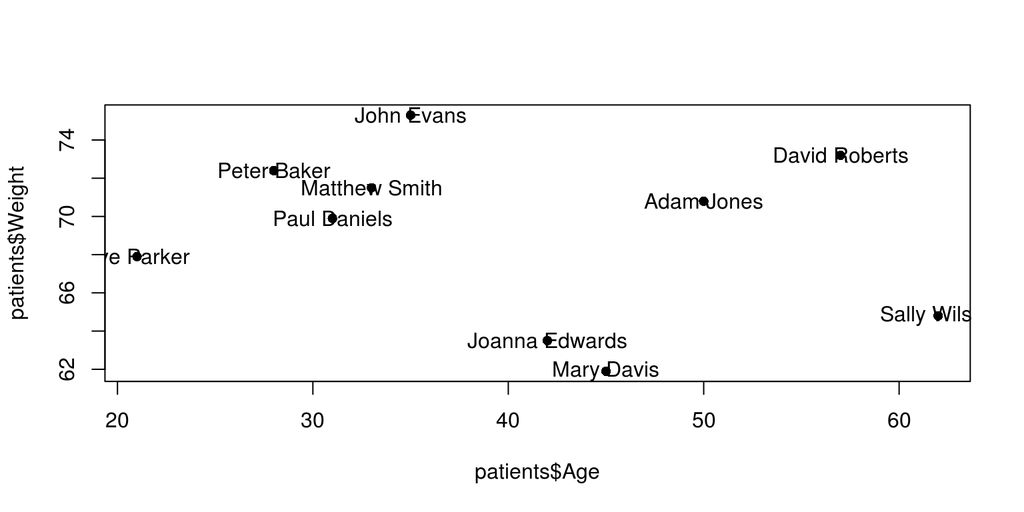

```r
plot(patients$Age, patients$Weight, pch=16)
text(patients$Age, patients$Weight, labels=patients$Full_Name)
```

# Adding text

- Can alter the positions so they don’t interfere with the points of the graph

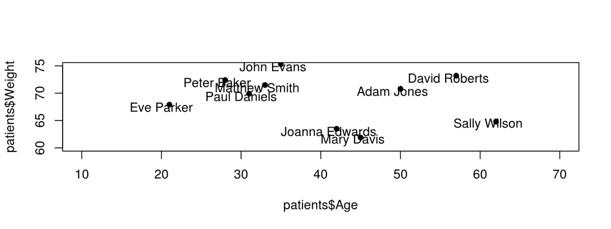

```r
plot(patients$Age, patients$Weight, pch=16,
     xlim=c(10,70), ylim=c(60,75))
text(patients$Age-1, patients$Weight-0.5,
     labels=patients$Full_Name)
```

- Alternatively, you can use the argument `adj`

# Adding lines

- To aid our interpretation, it is often helpful to add guidelines
  - `grid()` is one easy way of doing this:

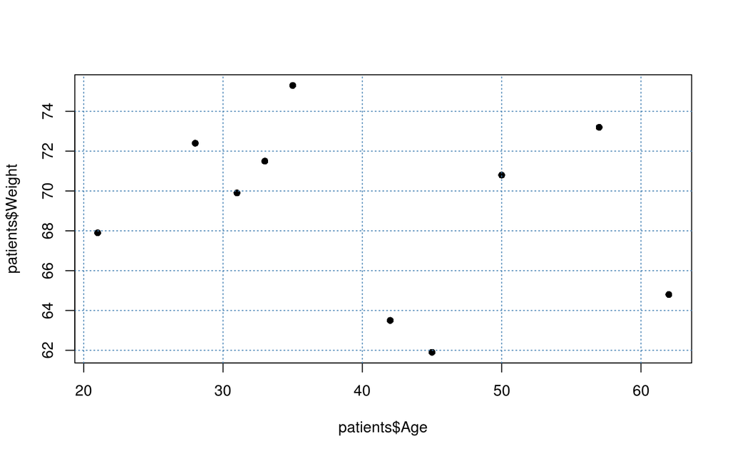

```r
plot(patients$Age, patients$Weight, pch=16)
grid(col="steelblue")
```

# Adding lines

- Can also add lines that intersect the axes:
  - `v =` for vertical lines
  - `h =` for horizontal
  - can specify multiple lines in a vector

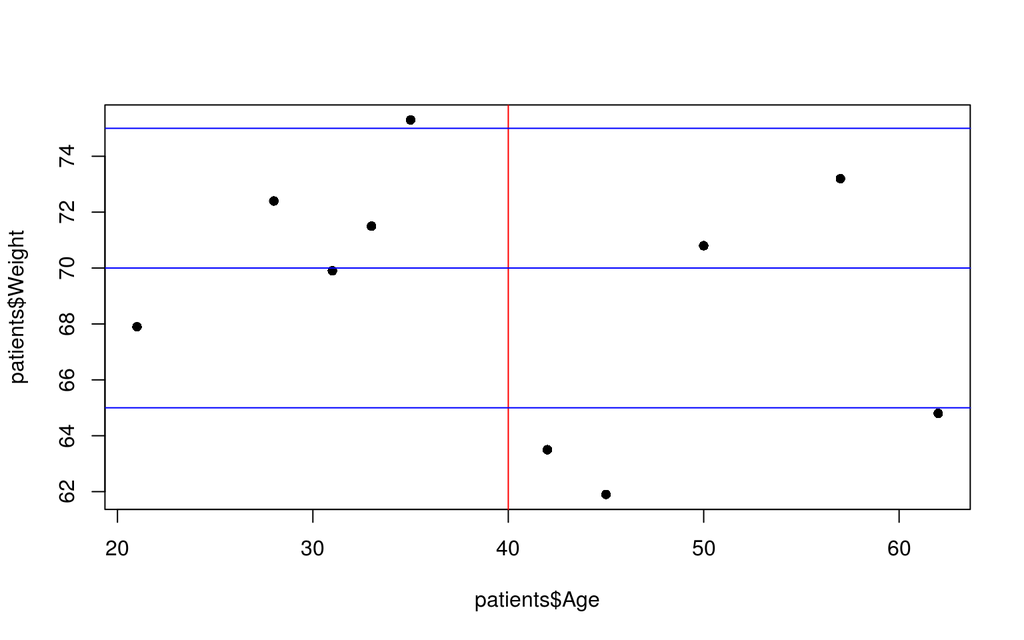

```r
plot(patients$Age, patients$Weight, pch=16)
abline(v=40, col="red")
abline(h=c(65,70,75), col="blue")
```

# Plot layouts

- The `par` function can be used specify the appearance of a plot
- The settings persist until the plot is closed with **`dev.off()`**
- `?par` and scroll to *graphical parameters*
- One example is `mfrow`:
  - “multiple figures per row”
  - needs to be a vector of rows and columns:
    - e.g. a plot with one row and two columns `par(mfrow=c(1,2))`
    - don’t need the same kind of plot in each cell

# Plot layouts

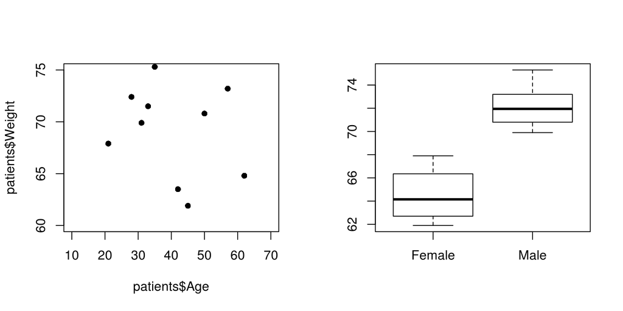

```r
par(mfrow=c(1,2))
plot(patients$Age, patients$Weight, pch=16,
     xlim=c(10,70), ylim=c(60,75))
boxplot(patients$Weight ~ patients$Sex)
```

- See also `mar` for setting the margins:
  - `par(mar=c(...))`

# Exporting graphs from RStudio

- Easiest option to to use the *Export* button from the *Plots* panel
- Otherwise, use the `pdf()` function:
  - You will see that the plot does not appear in RStudio

```r
pdf("ExampleGraph.pdf")
plot(rnorm(1:10))
```

- You need to use the `dev.off()` to stop printing graphs to the pdf and ‘close’ the file
  - It allows you to create a pdf document with multiple pages

```r
dev.off()
```

- pdf is a good choice for publication as they can be imported into Photoshop, Inkscape, etc.
  - Sometimes it is easier to edit in these tools than R!

# Exporting graphs from RStudio

- To save any graph you have created to a pdf, repeat the code you used to create the plot with `pdf()` before and `dev.off()` afterwards
  - you can have as many lines of code in-between as you like

```r
pdf("mygraph.pdf")
plot(patients$Age, patients$Weight, pch=16)
abline(v=40, col="red")
abline(h=c(65,70,75), col="blue")
dev.off()
```

# Exporting graphs from RStudio

- We can specify the dimensions of the plot, and other properties of the file (`?pdf`)

```r
pdf("ExampleGraph.pdf", width=10, height=10)
plot(rnorm(1:10))
dev.off()
```

- Other formats can be created:
  - e.g. *png*, or others `?jpeg`
  - more appropriate for email, presentations, web page

```r
png("ExampleGraph.png")
plot(rnorm(1:10))
dev.off()
```

# Exercise: exercise5.Rmd

- Return to the weather data from yesterday:

```r
weather <- read.csv("ozone.csv")
```

- Make a scatter plot of all observations of ozone level:
  - i.e. with the y axis being the Ozone variable, and x-axis being the row index
- Highlight any days in the study which had ozone level > 100
- Indicate which month these days with high ozone level belong to

# Target Graph

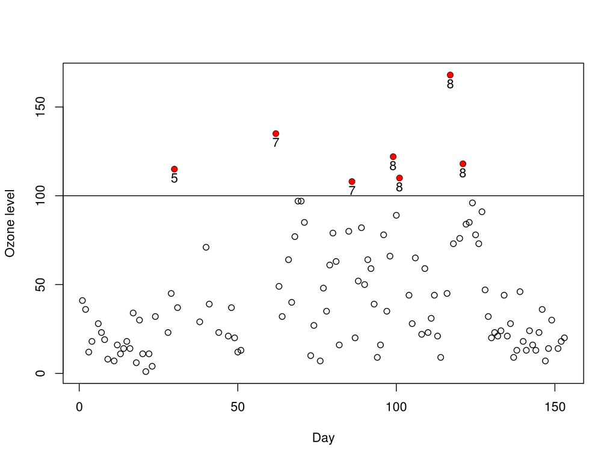

# Exercise: exercise5.Rmd

- Using the `par` function, create a layout with three columns
- Plot Ozone versus Solar Radiation, Wind Speed and Temperature on separate graphs
  - use different colours and plotting characters on each plot
- Save the plot to a pdf
- HINT: Create the graph first in RStudio, then when you’re happy with it, use the `pdf` function to save to a file

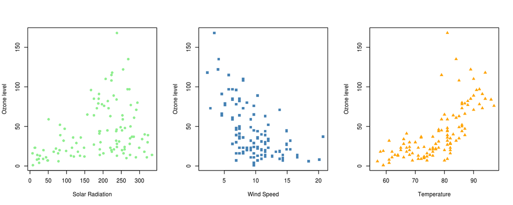

# Solution: solution-exercise5.pdf

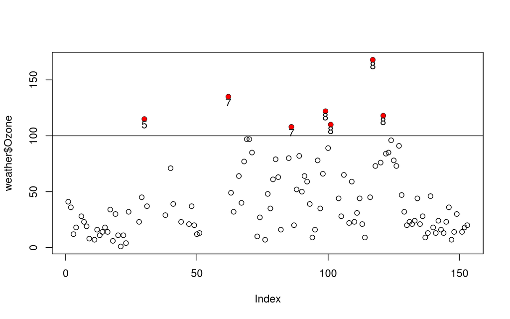

```r
plot(weather$Ozone)
abline(h=100)
highO <- which(weather$Ozone > 100)
points(highO, weather$Ozone[highO], col="red", pch=16)
text(highO,weather$Ozone[highO]-5, labels=weather$Month[highO])
```

- Note: check what is the difference of using:
  - `which(weather$Ozone > 100)`, or simply
  - `weather$Ozone > 100`

# Solution

```r
pdf("ozoneCorrelations.pdf")
par(mfrow=c(1,3))
plot(weather$Solar.R, weather$Ozone, pch=16,
     col="lightgreen", ylab="Ozone level",
     xlab="Solar Radiation")
plot(weather$Wind, weather$Ozone, pch=15,
     col="steelblue", ylab="Ozone level",
     xlab="Wind Speed")
plot(weather$Temp,weather$Ozone, pch=17,
     col="orange", ylab="Ozone level",
     xlab="Temperature")
dev.off()
```

# Solution

If the graph looks a bit stretched…

```r
pdf("ozoneCorrelations.pdf", width=10,height = 6)
par(mfrow=c(1,3))
plot(weather$Solar.R, weather$Ozone, pch=16,
     col="lightgreen", ylab="Ozone level",
     xlab="Solar Radiation")
plot(weather$Wind, weather$Ozone, pch=15,
     col="steelblue", ylab="Ozone level",
     xlab="Wind Speed")
plot(weather$Temp,weather$Ozone, pch=17,
     col="orange", ylab="Ozone level",
     xlab="Temperature")
dev.off()
```

# 2. Statistics

# Built-in support for statistics

- R is a statistical programming language:
  - Classical statistical tests are built-in
  - Statistical modeling functions are built-in
  - Regression analysis is fully supported
  - Additional mathematical packages are available (`MASS`, Waves, sparse matrices, etc)

# Distribution functions

- Most commonly used distributions are built-in, functions have stereotypical names, e.g. for normal distribution:
  - **`pnorm`** - cumulative distribution for x
  - **`qnorm`** - inverse of pnorm (from probability gives x)
  - **`dnorm`** - distribution density
  - **`rnorm`** - random number from normal distribution

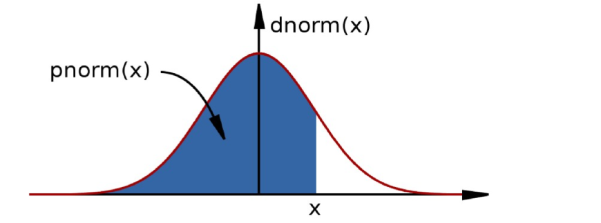

- Available for variety of distributions: `punif` (uniform), `pbinom` (binomial), `pnbinom` (negative binomial), `ppois` (poisson), `pgeom` (geometric), `phyper` (hyper-geometric), `pt` (T distribution), pf (F distribution)

# Distribution functions

- 10 random values from the Normal distribution with mean 10 and standard deviation 5:

```r
rnorm(10, mean=10, sd=5)
```

- The probability of drawing 10 from this distribution:

```r
dnorm(10, mean=10, sd=5)
```

```
[1] 0.07978846
```

```r
dnorm(100, mean=10, sd=5)
```

```
[1] 3.517499e-72
```

# Distribution functions (continued)

- The probability of drawing a value smaller than 10:

```r
pnorm(10, mean=10, sd=5)
```

```
[1] 0.5
```

- The inverse of `pnorm()`:

```r
qnorm(0.5, mean=10, sd=5)
```

```
[1] 10
```

- How many standard deviations for statistical significance?

```r
qnorm(0.95, mean=0, sd=1)
```

```
[1] 1.644854
```

# Example

Recall our histogram of temperature from yesterday:

- The data look to be roughly normally-distributed
- An assumption we rely on for various statistical tests

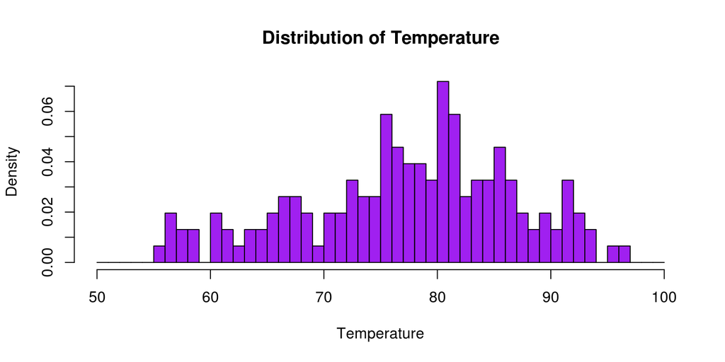

```r
hist(weather$Temp, col="purple", xlab="Temperature",
     main="Distribution of Temperature",
     breaks = 50:100, freq=FALSE)
```

# Create a normal distribution curve

- If our data are normally-distributed, we can calculate the probability of drawing particular values.
  - e.g. a temperature of 80

```r
tempMean <- mean(weather$Temp)
tempSD <- sd(weather$Temp)
dnorm(80, mean=tempMean, sd=tempSD)
```

- We can overlay this on the histogram using `points` as we just saw:

```r
hist(weather$Temp, col="purple", xlab="Temperature",
     main="Distribution of Temperature",
     breaks = 50:100, freq=FALSE)
points(80, dnorm(80, mean=tempMean, sd=tempSD),
       col="red", pch=16)
```

# Create a normal distribution curve

- We can repeat the calculation for a vector of values
  - remember that functions in R are often *vectorized*
  - use `lines` in this case rather than `points`

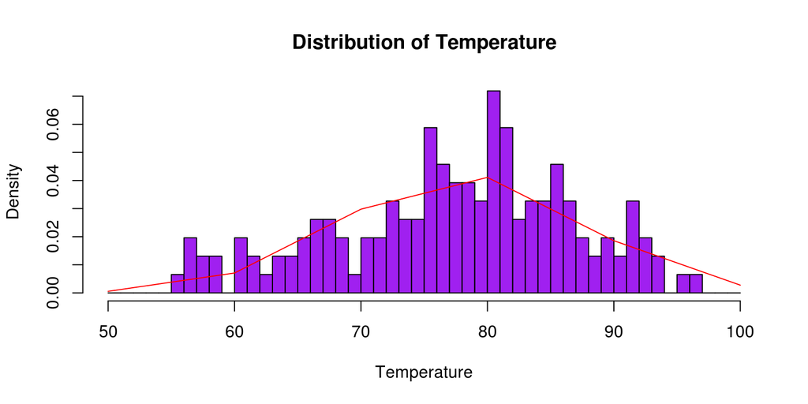

  ```r
  xs <- c(50,60,70,80,90,100)
  ys <- dnorm(xs, mean=tempMean, sd=tempSD)
  lines(xs, ys, col="red")
  ```

# Create a normal distribution curve

- For a smoother curve, use a longer vector:
  - We can generate x values using the `seq()` function

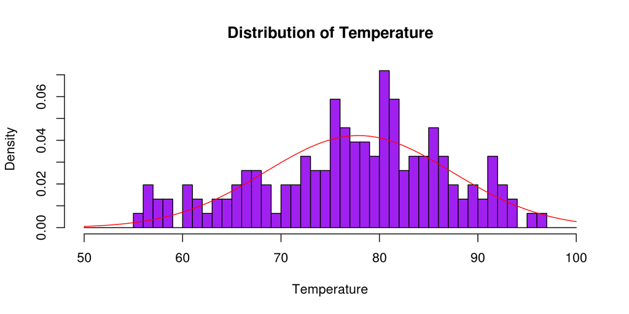

```r
xs <- seq(50,100, length.out = 10000)
ys <- dnorm(xs, mean=tempMean, sd=tempSD)
lines(xs, ys, col="red")
```

# Simple testing

- If we want to compute the probability of observing a particular temperature, from the same distribution we can use the standard formula to calculate a t statistic:

$t = \frac{\bar{x} -\mu_0}{s / \sqrt(n)}$

```r
t <- (tempMean - 50) / (tempSD/sqrt(length(weather$Temp)))
t
```

```
[1] 36.43696
```

# Simple testing

- …or use the **`t.test()`** function to compute the statistic and corresponding p-value

```r
t.test(weather$Temp, mu=50)
```

```
    One Sample t-test

data:  weather$Temp
t = 36.437, df = 152, p-value < 2.2e-16
alternative hypothesis: true mean is not equal to 50
95 percent confidence interval:
 76.37051 79.39420
sample estimates:
mean of x
 77.88235
```

# Two-sample tests: Basic data analysis

- Comparing 2 variances:
  - Fisher’s F test

```r
var.test()
```

- Comparing 2 sample means with normal errors:
  - Student’s t test

```r
t.test()
```

- Comparing 2 means with non-normal errors:
  - Wilcoxon’s rank test

```r
wilcox.test()
```

# Two-sample tests: Basic data analysis

- Comparing 2 proportions:
  - Binomial test

```r
prop.test()
```

- Correlating 2 variables:
  - Pearson’s / Spearman’s rank correlation

```r
cor.test()
```

- Testing for independence of 2 variables in a contingency table:
  - Chi-squared / Fisher’s exact test

```r
chisq.test(); fisher.test()
```

# Statistical tests in R

- Bottom-line: Pretty much any statistical test you care to name will probably be in R
  - This is not supposed to be a statistics course (sorry!)
  - None of them are particular harder than others to use
  - The difficulty is deciding which test to use:
    - whether the assumptions of the test are met, etc.
  - Consult your local statistician if not sure
  - Some good references:
    - [Simple R eBook](https://cran.r-project.org/doc/contrib/Verzani-SimpleR.pdf)
    - [Elements of Statistical Learning eBook](http://statweb.stanford.edu/~tibs/ElemStatLearn/download.html)

# Example analysis

- We have already seen that men in our `patients` dataset tend to be heavier than women
- We can **test this formally** in R

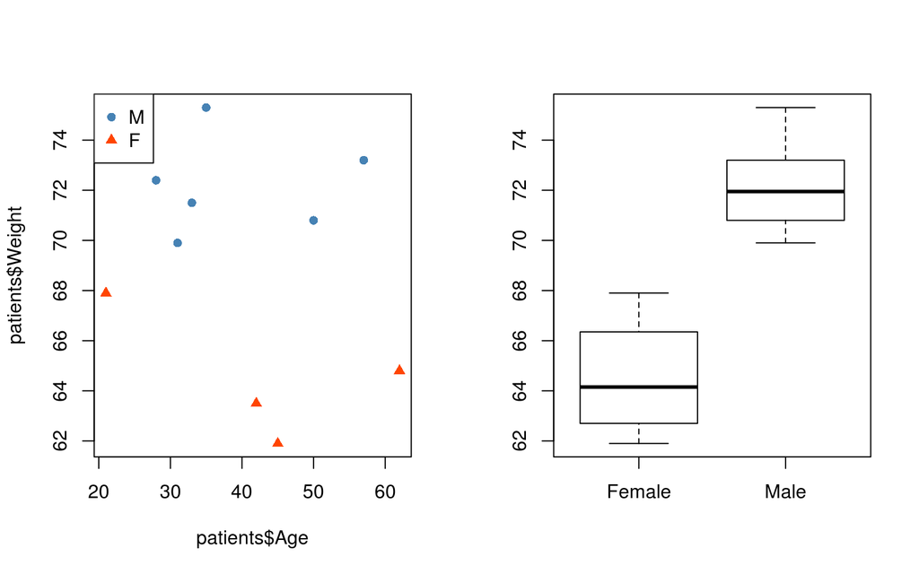

# Test variance assumption

```r
var.test(patients$Weight~patients$Sex)
```

```
    F test to compare two variances

data:  patients$Weight by patients$Sex
F = 1.759, num df = 3, denom df = 5, p-value = 0.5417
alternative hypothesis: true ratio of variances is not equal to 1
95 percent confidence interval:
  0.2265757 26.1830147
sample estimates:
ratio of variances
          1.759041
```

# Perform the t-test

```r
t.test(patients$Weight~patients$Sex, var.equal=TRUE)
```

```
    Two Sample t-test

data:  patients$Weight by patients$Sex
t = -5.4584, df = 8, p-value = 0.0006027
alternative hypothesis: true difference in means is not equal to 0
95 percent confidence interval:
 -10.893759  -4.422908
sample estimates:
mean in group Female   mean in group Male
            64.52500             72.18333
```

- This function can be tuned in various ways (`?t.test`):
  - Assumed equal variances, or not (and use Welch’s correction)
  - Deal with parired samples
  - Two-sided, or one-sided p-value

# Linear regression: Basic data analysis

- Linear modeling is supported by the function **`lm()`**:
  - `example(lm)`
  - The output assumes you know a fair bit about the subject
- `lm` is really useful for plotting lines of best fit to XY data, in order to determine intercept, gradient and Pearson’s correlation coefficient
  - This is very easy in R
- Three steps to plotting with a best fit line:
  1. Plot XY scatter-plot data
  2. Fit a linear model
  3. Add bestfit line data to plot with `abline()` function

# Typical linear regression analysis: Basic data analysis

- The ~ (*tilde*) is used to define a *formula*; i.e. “y is given by x”

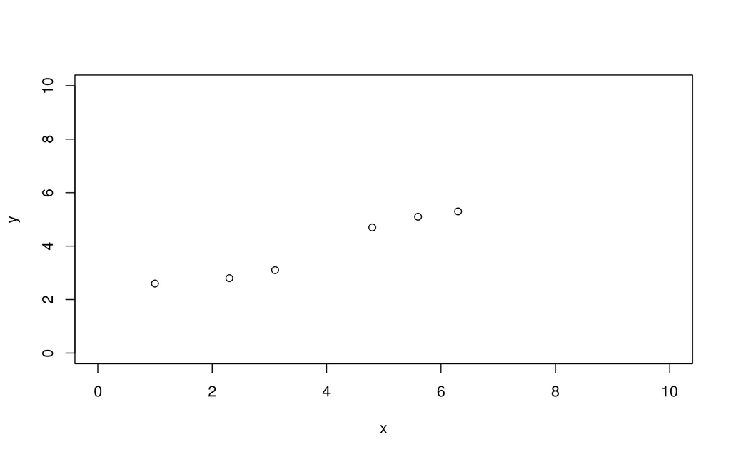

```r
x <- c(1, 2.3, 3.1, 4.8, 5.6, 6.3)
y <- c(2.6, 2.8, 3.1, 4.7, 5.1, 5.3)
plot(x,y, xlim=c(0,10), ylim=c(0,10))
```

# Typical linear regression analysis: Basic data analysis

The ~ is used to define a formula; i.e. “y is given by x” - Take care about the order of x and y in the plot and lm expressions

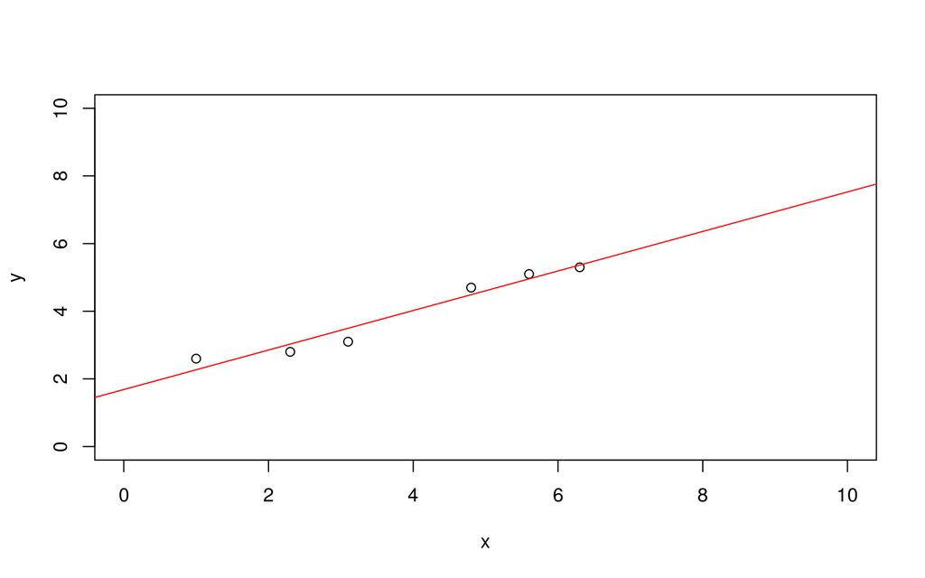

```r
plot(x,y, xlim=c(0,10), ylim=c(0,10))
myModel <- lm(y~x)
abline(myModel, col="red")
```

# In-depth summary

```r
summary(myModel)
```

```
Call:
lm(formula = y ~ x)

Residuals:
       1        2        3        4        5        6
 0.33159 -0.22785 -0.39520  0.21169  0.14434 -0.06458

Coefficients:
            Estimate Std. Error t value Pr(>|t|)
(Intercept)  1.68422    0.29056   5.796   0.0044 **
x            0.58418    0.06786   8.608   0.0010 **
---
Signif. codes:  0 '***' 0.001 '**' 0.01 '*' 0.05 '.' 0.1 ' ' 1

Residual standard error: 0.3114 on 4 degrees of freedom
Multiple R-squared:  0.9488,    Adjusted R-squared:  0.936
F-statistic:  74.1 on 1 and 4 DF,  p-value: 0.001001
```

# Typical linear regression analysis: Basic data analysis

- Get the coefficients of the fit from:

```r
coef(myModel)   # Coefficients
resid(myModel)  # Residuals
fitted(myModel) # Fitted values
names(myModel)  # Names of the objects within myModel
```

# Diagnostic plots of the fit

- Get QC of fit from:

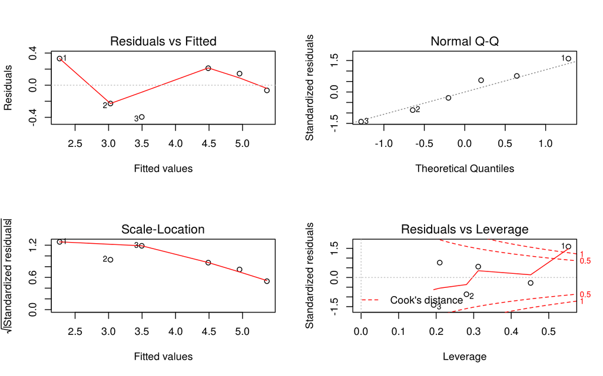

```r
par(mfrow=c(2,2))
plot(myModel)
```

# Modelling formulae

- R has a very powerful formula syntax for describing statistical models
- Suppose we had two explanatory variables `x` and `z`, and one response variable `y`
- We can describe a relationship between, say, `y` and `x` using a tilde `~`, placing the response variable on the left of the tilde and the explanatory variables on the right:
  - `y~x`
- It is very easy to extend this syntax to do multiple regressions, ANOVAs, to include interactions, and to do many other common modelling tasks. For example

```r
y~x       #If x is continuous, this is linear regression
y~x       #If x is categorical, ANOVA
y~x+z     #If x and z are continuous, multiple regression
y~x+z     #If x and z are categorical, two-way ANOVA
y~x+z+x:z # : is the symbol for the interaction term
y~x*z     # * is a shorthand for x+z+x:z
```

# Exercise: exercise6.Rmd

- There are suggestions that Ozone level could be influenced by Temperature:

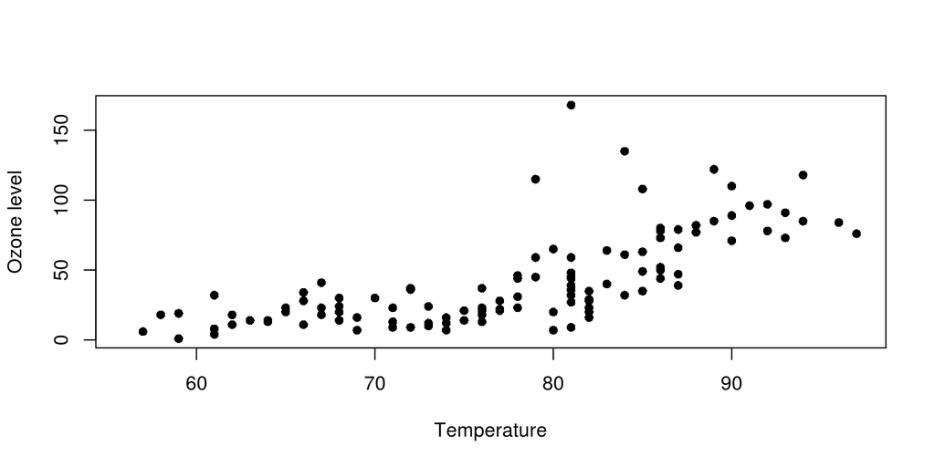

- Perform a linear regression analysis to assess this:
  - Fit the linear model and print a summary of the output
  - Plot the two variables and overlay a best-fit line

# Solution: solution-exercise6.pdf

```r
mod1 <- lm(weather$Ozone~weather$Temp)
summary(mod1)
```

```
Call:
lm(formula = weather$Ozone ~ weather$Temp)

Residuals:
    Min      1Q  Median      3Q     Max
-40.729 -17.409  -0.587  11.306 118.271

Coefficients:
              Estimate Std. Error t value Pr(>|t|)
(Intercept)  -146.9955    18.2872  -8.038 9.37e-13 ***
weather$Temp    2.4287     0.2331  10.418  < 2e-16 ***
---
Signif. codes:  0 '***' 0.001 '**' 0.01 '*' 0.05 '.' 0.1 ' ' 1

Residual standard error: 23.71 on 114 degrees of freedom
  (37 observations deleted due to missingness)
Multiple R-squared:  0.4877,    Adjusted R-squared:  0.4832
F-statistic: 108.5 on 1 and 114 DF,  p-value: < 2.2e-16
```

# Solution

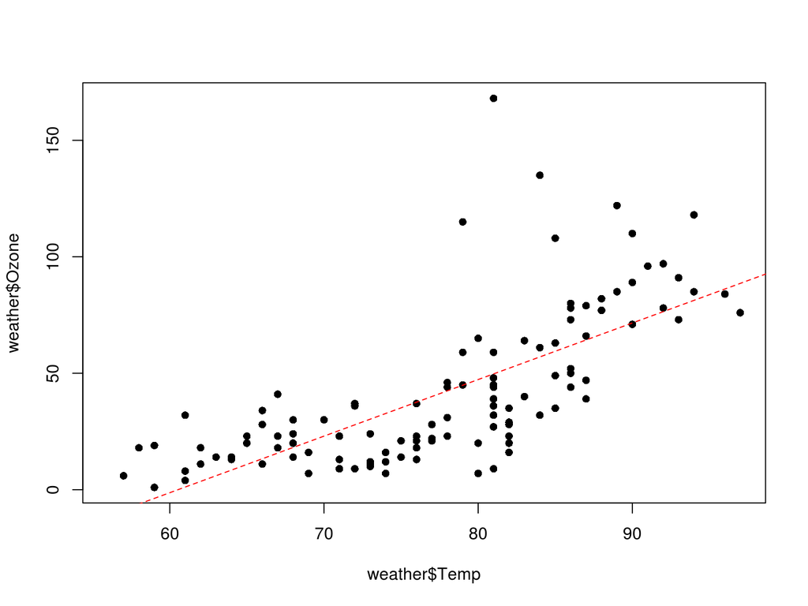

```r
plot(weather$Temp, weather$Ozone, pch=16)
abline(mod1, col="red", lty=2)
```

# Word of caution

*Correlation != Causation*

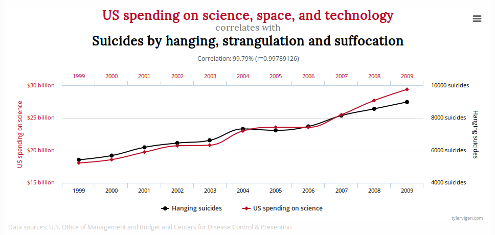

http://tylervigen.com/spurious-correlations

But no-one would ever take such trends seriously….would they?

# Wrong!

[figure not shown]

# 3. Data Manipulation Techniques

# Motivation

- So far we have been lucky that all our data have been in the same file:
  - This is not usually the case
  - Dataset may be spread over several files
    - This takes longer, and is harder, than many people realise
  - We need to combine before doing an analysis

# Combining data from multiple sources: Gene Clustering Example

- R has powerful functions to combine heterogeneous data sources into a single data set
- Gene clustering example data:
  - Gene expression values in *gene.expression.txt*
  - Gene information in *gene.description.txt*
  - Patient information in *cancer.patients.txt*
- A breast cancer dataset with numerous patient characteristics:
  - We will concentrate on *ER status* (positive / negative)
  - What genes show a statistically-significant different change between ER groups?

# Peek at the data

```r
evals <- read.delim("gene.expression.txt", stringsAsFactors = FALSE)
evals[1:2,1:5]
dim(evals)
```

```
                NKI_4 NKI_6  NKI_7  NKI_8 NKI_9
Contig56678_RC -0.261 0.346  0.047 -1.140 -0.11
AF026004       -0.064 0.040 -0.165 -0.031  0.33
```

```
[1] 498 337
```

- 498 rows and 337 columns
- One row for each gene:
  - Rows are named according to particular technology used to make measurement
  - The names of each row can be returned by `rownames(evals)`; giving a vector
- One column for each patient:
  - The names of each column can be returned by `colnames(evals)`; giving a vector

# Peek at the data

```r
genes <- read.delim("gene.description.txt",stringsAsFactors = FALSE)
head(genes)
```

```
                        probe HUGO.gene.symbol Chromosome     Start
Contig56678_RC Contig56678_RC            THSD4      chr15  71433788
AF026004             AF026004            CLCN2       chr3 184063973
AB033049             AB033049          ANKRD50       chr4 125585207
AB033050             AB033050            ZMIZ1      chr10  80828792
AB033086             AB033086           NLGN4X       chrX   5808083
NM_003008           NM_003008            SEMG2      chr20  43850010
```

```r
dim(genes)
```

```
[1] 498   4
```

- 498 rows and 4 columns
- One for for each gene
- Includes mapping between manufacturer ID and Gene name

# Peek at the data

```r
subjects <- read.delim("cancer.patients.txt")
head(subjects)
```

```
       samplename age er grade
NKI_4       NKI_4  41  1     3
NKI_6       NKI_6  49  1     2
NKI_7       NKI_7  46  0     1
NKI_8       NKI_8  48  0     3
NKI_9       NKI_9  48  1     3
NKI_11     NKI_11  37  1     3
```

```r
dim(subjects)
```

```
[1] 337   4
```

- One for each patient in the study
- Each column is a different characteristic of that patient
  - e.g. whether a patient is ER positive or negative

```r
table(subjects$er)
```

```
  0   1
 88 249
```

# Ordering and sorting

To get a feel for these data, we will look at how we can subset and order

- R allows us to do the kinds of filtering, sorting and ordering operations you might be familiar with in Excel
- For example, if we want to get information about patients that are ER negative
  - these are indicated by an entry of *0* in the `er` column

```r
subjects$er == 0
```

```
[1] "FALSE" "FALSE" "..."   "FALSE" "FALSE"
```

# Ordering and sorting

We can do the comparison within the square brackets

- Remembering to include a `,` to index the columns as well
- Best practice to create a new variable and leave the original data frame untouched

```r
erNegPatients <- subjects[subjects$er == 0,]
head(erNegPatients)
```

```
       samplename age er grade
NKI_7       NKI_7  46  0     1
NKI_8       NKI_8  48  0     3
NKI_12     NKI_12  46  0     3
NKI_24     NKI_24  49  0     3
NKI_28     NKI_28  40  0     3
NKI_44     NKI_44  53  0     3
```

# Ordering and sorting

Sorting is supported by the **`sort()`** function

- Given a vector, it will return a sorted version of the same length

```r
sort(erNegPatients$grade)
```

```
 [1] "1"   "1"   "1"   "1"   "1"   "2"   "2"   "2"   "2"   "2"   "..."
[12] "3"   "3"   "3"   "3"   "3"   "3"   "3"   "3"   "3"
```

- But this is not useful in all cases
  - We have lost the extra information that we have about the patients

# Ordering and sorting

- Instead, we can use **`order()`**
- Given a vector, `order()` will give a set of numeric values which will give an ordered version of the vector
  - default is smallest –> largest

```r
myvec <- c(9,10,4,3,8,5,6,2,1,7)
myvec
```

```
 [1]  9 10  4  3  8  5  6  2  1  7
```

```r
order(myvec)
```

```
 [1]  9  8  4  3  6  7 10  5  1  2
```

- i.e. number in position 9 is the smallest, number in position 8 is the second smallest:

```r
myvec[9]
```

```
[1] 1
```

```r
myvec[8]
```

```
[1] 2
```

# Ordering and sorting

- We can use the result of `order()` to perform a subset of our original vector
- The result is an ordered vector

```r
myvec.ord <- myvec[order(myvec)]
myvec.ord
```

```
 [1]  1  2  3  4  5  6  7  8  9 10
```

- Implication: We can use `order` on a particular column of a data frame, and use the result to sort all the rows

# Ordering and sorting

- Here we order the `age` column and use the result to re-order the rows in the data frame

```r
erNegPatientsByAge <- erNegPatients[order(erNegPatients$age),]
head(erNegPatientsByAge)
```

```
        samplename age er grade
NKI_330    NKI_330  26  0     3
NKI_57      NKI_57  28  0     3
NKI_230    NKI_230  28  0     3
NKI_90      NKI_90  29  0     3
NKI_48      NKI_48  30  0     3
NKI_86      NKI_86  30  0     3
```

# Ordering and sorting

- can change the behaviour of `order` to be Largest –> Smallest

```r
erNegPatientsByAge <- erNegPatients[order(erNegPatients$age,decreasing = TRUE),]
head(erNegPatientsByAge)
```

```
        samplename age er grade
NKI_96      NKI_96  62  0     3
NKI_93      NKI_93  61  0     3
NKI_119    NKI_119  54  0     3
NKI_44      NKI_44  53  0     3
NKI_75      NKI_75  52  0     3
NKI_76      NKI_76  52  0     2
```

- we can write the result to a fie if we wish

```r
write.table(erNegPatientsByAge, file="erNegativeSubjectsByAge.txt", sep="\t")
```

# Exercise: exercise7.Rmd

- Imagine we want to know information about chromosome 8 genes that have been measured.
1. Create a new data frame containing information on genes on Chromosome 8
2. Order the rows in this data frame according to start position, and write the results to a file

# Solution: solution-exercise7.pdf

```r
chr8Genes <- genes[genes$Chromosome=="chr8",]
head(chr8Genes)
```

```
                        probe HUGO.gene.symbol Chromosome     Start
Contig29827_RC Contig29827_RC            FUT10       chr8  33228344
NM_003046           NM_003046           SLC7A2       chr8  17396286
Contig55940_RC Contig55940_RC            CYHR1       chr8 145675315
NM_004133           NM_004133            HNF4G       chr8  76452203
NM_004374           NM_004374            COX6C       chr8 100890223
AF052142             AF052142            NCALD       chr8 102698770
```

```r
chr8GenesOrd <- chr8Genes[order(chr8Genes$Start),]
head(chr8GenesOrd)
```

```
                        probe HUGO.gene.symbol Chromosome    Start
NM_004745           NM_004745           DLGAP2       chr8  1449569
NM_018941           NM_018941             CLN8       chr8  1711870
AL117604             AL117604             DLC1       chr8 12940872
NM_003046           NM_003046           SLC7A2       chr8 17396286
Contig58301_RC Contig58301_RC           SLC7A2       chr8 17396286
NM_000662           NM_000662             NAT1       chr8 18067618
```

```r
write.table(chr8GenesOrd, "chromosome8.gene.info.txt", sep="\t")
```

# Retrieving data for a particular gene

- Gene `ESR1` is known to be hugely-different between ER positive and negative patient
  - let’s check that this is evident in our dataset
  - if not, something has gone wrong!
- First step is to locate this gene in our dataset

# Character matching in R

- We have already seen various ways of comparing numeric values
  - ==, >, <
  - each of which returns a vector of logical values
  - == will also work with text

```r
LETTERS
```

```
 [1] "A" "B" "C" "D" "E" "F" "G" "H" "I" "J" "K" "L" "M" "N" "O" "P" "Q"
[18] "R" "S" "T" "U" "V" "W" "X" "Y" "Z"
```

```r
"A" == LETTERS
```

```
 [1]  TRUE FALSE FALSE FALSE FALSE FALSE FALSE FALSE FALSE FALSE FALSE
[12] FALSE FALSE FALSE FALSE FALSE FALSE FALSE FALSE FALSE FALSE FALSE
[23] FALSE FALSE FALSE FALSE
```

# Character matching in R

- `match()` and `grep()` are often used to find particular matches
  - CAUTION: by default, match will only return the *first* match!

```r
match("D", LETTERS)
```

```
[1] 4
```

```r
grep("F", rep(LETTERS,2))
```

```
[1]  6 32
```

```r
match("F", rep(LETTERS,2))
```

```
[1] 6
```

# Retrieving data for a particular gene

- Find the name of the ID that corresponds to gene *ESR1*
  - mapping between IDs and genes is in the *genes* data frame
    - ID in first column, gene name in the second
- Save this ID as a variable

```r
ind <- match("ESR1", genes$HUGO.gene.symbol)
genes[ind,]
```

```
              probe HUGO.gene.symbol Chromosome     Start
NM_000125 NM_000125             ESR1       chr6 152128814
```

```r
probe <- genes[ind,1]
probe
```

```
[1] "NM_000125"
```

# Retrieving data for a particular gene

Now, find which row in our expression matrix is indexed by this ID

- recall that the rownames of the expression matrix are the probe IDs
- save the expression values as a variable

```r
match(probe, rownames(evals))
```

```
[1] 384
```

```r
evals[match(probe, rownames(evals)), 1:10]
```

```
           NKI_4 NKI_6  NKI_7 NKI_8 NKI_9 NKI_11 NKI_12 NKI_13 NKI_14
NM_000125 -0.007 0.074 -0.767 -0.82 -0.18 -0.296     NA -0.163  0.059
          NKI_17
NM_000125 -0.035
```

```r
genevals <- evals[match(probe,rownames(evals)),]
```

# Relating to patient characteristics

We have numeric expression values and want to visualise them against our categorical data

- use a boxplot, for example

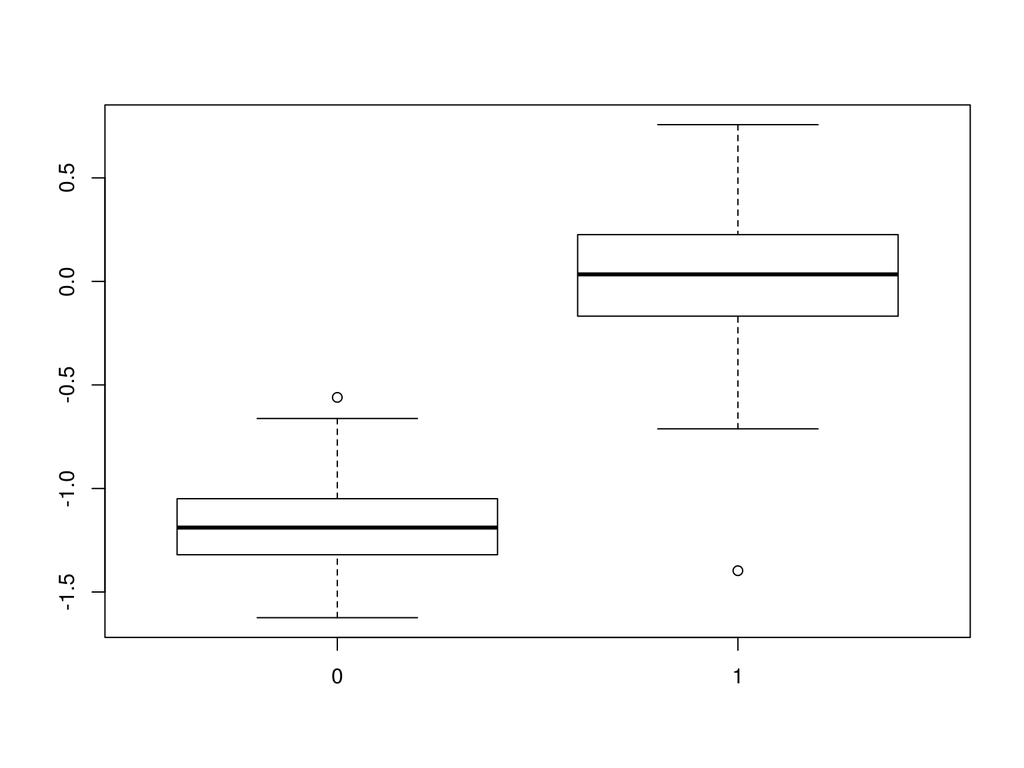

```r
boxplot(as.numeric(genevals) ~ factor(subjects$er))
```

# Relating to patient characteristics

- The p-value is also encouraging

```r
t.test(as.numeric(genevals) ~ factor(subjects$er))
```

```
    Welch Two Sample t-test

data:  as.numeric(genevals) by factor(subjects$er)
t = -38.746, df = 205.88, p-value < 2.2e-16
alternative hypothesis: true difference in means is not equal to 0
95 percent confidence interval:
 -1.246953 -1.126198
sample estimates:
mean in group 0 mean in group 1
    -1.17388506      0.01269076
```

# Complete script

`esr1Example.Rmd`

```r
genes    <- read.delim("gene.description.txt")
subjects <- read.delim("cancer.patients.txt")
evals    <- read.delim("gene.expression.txt", stringsAsFactors = FALSE)

ind      <- match("ESR1", genes[,2])
probe    <- genes[ind,1]
genevals <- evals[match(probe,rownames(evals)),]

boxplot(as.numeric(genevals) ~ factor(subjects$er))
t.test(as.numeric(genevals) ~ factor(subjects$er))
```

# Exercise: exercise8.Rmd

Repeat the same steps we performed for the gene ESR1, but for GATA3:

- Try and make as few changes as possible from the ESR1 script
- Can you see why making a markdown document is useful for analysis?

# 4. Programming in R

# Motivation

From the previous exercise, you should see how we can easily adapt our markdown scripts:

- e.g. ESR1 versus GATA3
- But what if we want to analyse many genes?
- It would be tedious to create a new markdown document for every gene
- …and prone to error too

# Introducing loops

- Many programming languages have ways of doing the same thing many times, perhaps changing some variable each time. This is called **looping**
- Loops are not used in R so often, because we can usually achieve the same thing using vector calculations
- For example, to add two vectors together, we do not need to add each pair of elements one by one, we can just add the vectors

```r
x <- 1:10
y <- 11:20
x+y
```

- But there are some situations where R functions can not take vectors as input. For example, `t.test()` will only test one gene at a time
- What if we wanted to test multiple genes?

# Introducing loops

- We could do this:

```r
t.test(evals[1,] ~ factor(subjects$er))
t.test(evals[2,] ~ factor(subjects$er))
```

- But this will be boring to type, difficult to change, and prone to error
- As we are doing the same thing multiple times, but with a different index each time, we can use a **loop** instead

# Loops: Commands and flow control

- R has two basic types of loop
  - a **`for`** loop: run some code on every value in a vector
  - a **`while`** loop: run some code while some condition is true (*hardly ever used!*)

`for`

```r
for(i in 1:10) {
  print(i)
  }
```

`while`

```r
i <- 1
while(i <= 10 ) {
  print(i)
  i <- i + 1
  }
```

# Loops: Commands and flow control

- Here’s how we might use a `for` loop to test the first 10 genes

```r
for(i in 1:10) {
  t.test(as.numeric(evals[i,]) ~ factor(subjects$er))
  }
```

- This is exactly the same as:

```r
i <- 1
t.test(evals[i,] ~ factor(subjects$er))
i <- 2
t.test(evals[i,] ~ factor(subjects$er))
i <- 3
...
```

# Storing results

However, this for loop is doing the calculations but not storing the results

- The output of `t.test()` is an object with data placed in different slots
  - the `names()` of the object tells us what data we can retrieve, and what name to use
  - N.B it is a “list” object

```r
t <- t.test(as.numeric(evals[1,]) ~ factor(subjects$er))
names(t)
```

```
[1] "statistic"   "parameter"   "p.value"     "conf.int"    "estimate"
[6] "null.value"  "alternative" "method"      "data.name"
```

```r
t$statistic
```

```
        t
-20.12546
```

# Storing results

- When using a loop, we often create an empty “dummy” variable
- This is used store the results at each stage of the loop

```r
stats <- NULL
for(i in 1:10) {
  tmp <- t.test(as.numeric(evals[i,]) ~ factor(subjects$er))
  stats[i] <- tmp$statistic
  }
stats
```

```
 [1] -20.1254643  -1.7973581  -9.2625540  -3.3080720   0.7512869
 [6]  -0.6220547  -0.2596520  -4.1309155  -1.7027881 -16.1224377
```

# Practical application

Previously we have identified probes on chromosome 8

- Lets say that we want to do a t-test for each gene on chromosome 8

```r
head(chr8GenesOrd)
```

```
                        probe HUGO.gene.symbol Chromosome    Start
NM_004745           NM_004745           DLGAP2       chr8  1449569
NM_018941           NM_018941             CLN8       chr8  1711870
AL117604             AL117604             DLC1       chr8 12940872
NM_003046           NM_003046           SLC7A2       chr8 17396286
Contig58301_RC Contig58301_RC           SLC7A2       chr8 17396286
NM_000662           NM_000662             NAT1       chr8 18067618
```

- The first step is to extract the expression values for chromosome 8 genes from our expression matrix, which has expression values for all genes
- We can use the `match` function to tell us which rows in the matrix correspond to chromosome 8 genes

```r
match(chr8GenesOrd$probe, rownames(evals))
```

```
 [1] 215 494 161   8 481 461 140 478   7  87 256 139 449 128 138 176 201
[18]  77
```

```r
chr8Expression <- evals[match(chr8GenesOrd$probe, rownames(evals)),]
dim(chr8Expression)
```

```
[1]  18 337
```

# Exercise: exercise9.Rmd

- Create a for loop to perform to test if the expression level of each gene on chromosome 8 is significantly different between ER positive and negative samples
- Store the *p-value* from each individual test

# Solution: solution-exercise9.pdf

```r
pvals <- NULL
for(i in 1:18) {
  tmp <- t.test(as.numeric(chr8Expression[i,]) ~ factor(subjects$er))
  pvals[i] <- tmp$p.value
  }
pvals
```

```
 [1] 5.464153e-03 2.408701e-01 5.842811e-05 6.611391e-05 2.590922e-57
 [6] 2.564435e-69 9.382548e-01 7.555477e-01 7.955434e-01 2.088048e-01
[11] 2.695280e-01 5.440249e-01 3.764754e-02 2.297528e-37 2.077849e-04
[16] 2.188104e-03 1.340043e-12 2.169950e-08
```

# Conditional branching: Commands and flow control

- Use an `if` statement for any kind of condition testing
- Different outcomes can be selected based on a condition within brackets

```r
if (condition) {
  ... do this ...
  } else {
    ... do something else ...
    }
```

- `condition` is any logical value, and can contain multiple conditions.
  - e.g. `(a == 2 & b < 5)`, this is a compound conditional argument
- The condition should return a *single* value of `TRUE` or `FALSE`

# Other conditional tests

- There are various tests that can check the type of data stored in a variable
  - these tend to be called **`is...()`**.
    - try *tab-complete* on `is.`

```r
is.numeric(10)
```

```
[1] TRUE
```

```r
is.numeric("TEN")
```

```
[1] FALSE
```

```r
is.character(10)
```

```
[1] FALSE
```

- `is.na()` is useful for seeing if an `NA` value is found
  - cannot use `== NA`!

```r
match("foo", genes[,2])
```

```
[1] NA
```

```r
is.na(match("foo", genes[,2]))
```

```
[1] TRUE
```

# Conditional branching: Commands and flow control

- Using the **`for`** loop we wrote before, we could add some code to plot the expression of each gene
  - a boxplot would be ideal
- However, we might only want plots for genes with a “significant” pvalue
- Here’s how we can use an `if` statement to test for this
  - for each iteration of the the loop:
    1. test if the p-value from the test is below 0.05 or not
    2. if the p-value is less than 0.05 make a boxplot
    3. if not, do nothing

```r
pdf("Chromosome8Genes.pdf")
pvals <- NULL
for (i in 1:18) {
  tmp <- t.test(as.numeric(chr8Expression[i,]) ~ factor(subjects$er))
  pvals[i] <- tmp$p.value
  if(tmp$p.value < 0.05){
    boxplot(as.numeric(chr8Expression[i,]) ~ factor(subjects$er),
            main=chr8Genes$HUGO.gene.symbol[i])
    }
  }
pvals
dev.off()
```

# Code formatting avoids bugs!

Compare:

```r
f<-26
while(f!=0){
print(letters[f])
f<-f-1}
```

to:

```r
f <- 26
while(f != 0 ){
  print(letters[f])
  f <- f-1
  }
```

- The code between brackets `{}` *always* is *indented*, this clearly separates what is executed once, and what is run multiple times
- Trailing bracket `}` always alone on the line at the same indentation level as the initial bracket `{`
- Use white spaces to divide the horizontal space between units of your code, e.g. around assignments, comparisons

# 5. Report Writing

# Creating a markdown file from scratch

*File → New File → R Markdown*

- Choose ‘Document’ and the default output type (HTML)
- A new tab is created in RStudio
- The header allows you to specify a Page title, author and output type

```r
---
title: "Untitled"
author: "Mark Dunning"
date: "18/08/2015"
output: html_document
---
```

# Format of the file

- **Lines 8 - 10**: Plain text description
- **Lines 12 - 14**: An R code ‘chunk’
- **Lines 18 to 20**: Another code chunk, this time producing a plot

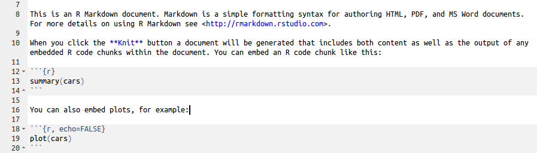

- Pressing the *Knit HTML* button will create the report:
  - Note that you need to ‘save’ the markdown file before you will see the compiled report in your working directory

# Text formatting

See *?* → *Markdown Quick Reference* in RStudio:

- Enclose text in * to format in *italics*
- Enclose text in ** to format in **bold**
- *** for *bold italics*
- ` to format like `code`
- $ to include equations: $e =mc^2$
- > quoted text:

> To be or not to be
- See *Markdown Quick Reference** for more:
  - Adding images
  - Adding web links
  - Tables

# Not quite enough for a reproducible document

# Defining chunks

- It is not great practice to have one long, continuous R script
- Better to break-up into smaller pieces; ‘*chunks*’
- You can document each chunk separately
- Easier to catch errors
- The characteristics of each chunk can be modified:
  - You might not want to print the R code for each chunk
  - …or the output
  - etc.

# Chunk options

Code chunks are encapsulated between backticks. Options for the chunk can be put inside the curly brackets`{...}`

```
'''{r}
my code here...
'''
```

- It’s a good idea to name each chunk
  - Easier to track-down errors
- We can display R code, but not run it
  - `eval=FALSE`
- We can run R code, but not display it
  - `echo=FALSE`
  - e.g. setting display options
- Suppress warning messages
  - `warning=FALSE`

# Chunk options: eval

- Sometimes we want to format code for display, but not execute; we want to show the code for how we read our data, but want our report to compile quickly

```
'''{r, eval=FALSE}
data <- read.delim("path.to.my.file")
'''
```

# Chunk options: echo

- Might want to load some data from disk
  - e.g. the R object from reading the data in the previous slide

    ```
    '''{r echo=FALSE}
    load("mydata.rda")
    '''
    ```

- Your P.I. wants to see your results, but doesn’t really want to know about the R code that you used

# Chunk options: results

- Some code or functions might produce lots of output to the screen that we don’t need

```r
for(i in 1:100) {
  print(i)
  }
```

# Chunk options: message and warning

- Loading an R package will sometimes print messages and / or warnings to the screen
- This is not always helpful in a report:

  ```
  '''{r}
  library(DESeq)
  '''
  ```

```
locfit 1.5-9.1   2013-03-22
    Welcome to 'DESeq'. For improved performance, usability and
    functionality, please consider migrating to 'DESeq2'.
```

# Chunk options: message and warning

- Using `message=FALSE` and `warning=FALSE`

  ```
  '''{r message=FALSE, warning=FALSE}
  library(DESeq)
  '''
  ```

- Could also need `suppressPackageStartupMessages`

# Chunk options: cache

- The argument `cache=TRUE` will stop certain chunks from being evaluate if their code does not change
- It speeds-up the compilation of the document
  - we don’t want to reload our dataset if we’ve only made a tiny change downstream

    ```
    '''{r echo=FALSE, cache=TRUE}
    load("mydata.rda")
    '''
    ```

# Running R code from the main text

- We can add R code to our main text, which gets evaluated
  - make sure we always have the latest figures, p-values etc

```
'''
...the sample population consisted of 'r table(gender)[1]' females
and 'r table(gender)[2]' males...
'''
```

…the sample population consisted of 47 females and 50 males…

- Alternatively:

```
'''
...the p-value of the t-test is 'r pval', which indicates that...
'''
```

…the p-value of the t-test is 0.05, which indicates that…

- We call this **“in-line” code**

# Running R code from the main text

- Like the rest of our report these R statements will get updated each time we compile the report

```
'''
...the sample population consisted of 'r table(gender)[1]' females
and 'r table(gender)[2]' males...
'''
```

…the sample population consisted of 41 females and 54 males…

```
'''
...the p-value of the t-test is 'r pval', which indicates that...
'''
```

…the p-value of the t-test is 0.1, which indicates that…

# Making a heatmap

- A heatmap is often used to visualise how the expression level of a set of genes vary between conditions
- Making the plot is actually quite straightforward
  - providing you have processed the data appropriately!
  - here, we use `na.omit()` to ensure we have no `NA` values

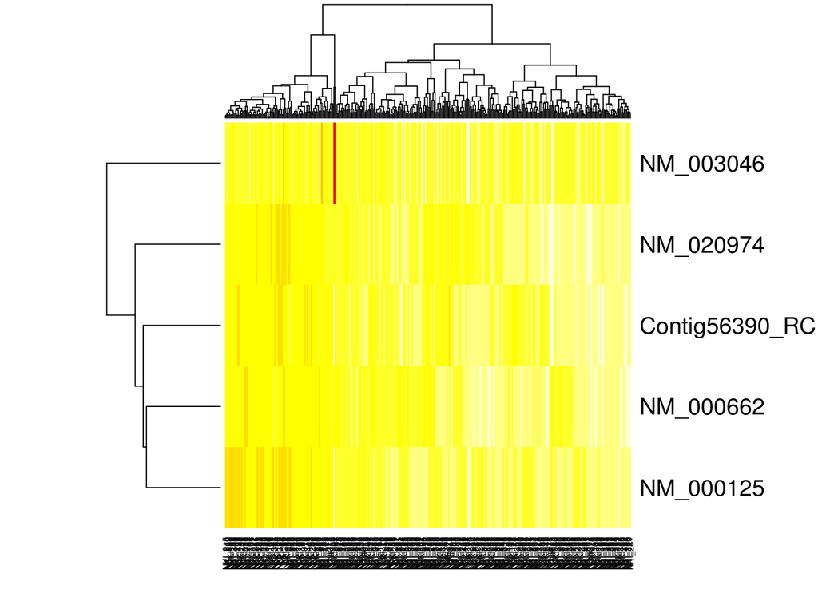

```r
genelist <- c("ESR1", "NAT1", "SUSD3","SLC7A2" ,"SCUBE2")
probes   <- na.omit(genes[match(genelist, genes[,2]), 1])
exprows  <- match(probes, rownames(evals))

heatmap(as.matrix(evals[exprows,]))
```

# Heatmap adjustments

- We can provide a colour legend for the samples
- Adjust colour of cells

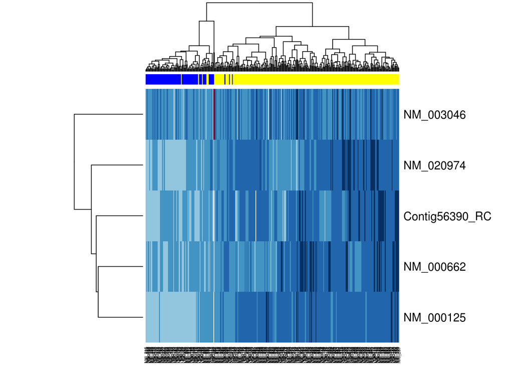

```r
library(RColorBrewer)
sampcol <- rep("blue", ncol(evals))
sampcol[subjects$er == 1 ] <- "yellow"
rbPal <- brewer.pal(10, "RdBu")
heatmap(as.matrix(evals[exprows,]), ColSideColors = sampcol, col=rbPal)
```

- see also
  - `heatmap.2` from `library(gplots)`; `example(heatmap.2)`
  - `heatmap.plus` from `library(heatmap.plus)`; `example(heatmap.plus)`

# Exercise

This analysis is recorded in `exercise10.Rmd`.

- Use in-line R code to report how many patients were involved in the study
- Hide the code chunk used to produce the plot (`echo=FALSE`)
- Cache the code chunk used to read the raw data (`cache=TRUE`)

Solution: solution-exercise10.Rmd

# End of Course

# Wrap-up

- **Thanks for your attention**
- Practice, practice, practice
  - … & persevere
- Need inspiration? R code is freely-availabe, so read other people’s code!
  - Read [blogs](http://www.r-bloggers.com/)
  - Follow the [forums](http://stackoverflow.com/questions/tagged/r)
  - Download [datasets](http://vincentarelbundock.github.io/Rdatasets/datasets.html) to practice with
  - Bookmark some [reference](https://en.wikibooks.org/wiki/R_Programming) guides
  - on twitter @rstudio, @Rbloggers, @RLangTip
- Please fill in the feedback form for us to improve the course